# Análise de Vinhos por André Miranda

# Seção de Gráficos Univariados

```
## [1] 4898   13
```

```
## 'data.frame':    4898 obs. of  13 variables:
##  $ X                   : int  1 2 3 4 5 6 7 8 9 10 ...
##  $ fixed.acidity       : num  7 6.3 8.1 7.2 7.2 8.1 6.2 7 6.3 8.1 ...
##  $ volatile.acidity    : num  0.27 0.3 0.28 0.23 0.23 0.28 0.32 0.27 0.3 0.22 ...
##  $ citric.acid         : num  0.36 0.34 0.4 0.32 0.32 0.4 0.16 0.36 0.34 0.43 ...
##  $ residual.sugar      : num  20.7 1.6 6.9 8.5 8.5 6.9 7 20.7 1.6 1.5 ...
##  $ chlorides           : num  0.045 0.049 0.05 0.058 0.058 0.05 0.045 0.045 0.049 0.044 ...
##  $ free.sulfur.dioxide : num  0.045 0.014 0.03 0.047 0.047 0.03 0.03 0.045 0.014 0.028 ...
##  $ total.sulfur.dioxide: num  0.17 0.132 0.097 0.186 0.186 0.097 0.136 0.17 0.132 0.129 ...
##  $ density             : num  1.001 0.994 0.995 0.996 0.996 ...
##  $ pH                  : num  3 3.3 3.26 3.19 3.19 3.26 3.18 3 3.3 3.22 ...
##  $ sulphates           : num  0.45 0.49 0.44 0.4 0.4 0.44 0.47 0.45 0.49 0.45 ...
##  $ alcohol             : num  8.8 9.5 10.1 9.9 9.9 10.1 9.6 8.8 9.5 11 ...
##  $ quality             : int  6 6 6 6 6 6 6 6 6 6 ...
```

Nosso conjunto de dados possui 13 variáveis e um total de 4898 observações. Podemos notar que X é somente uma variável de índice, podendo ser descartada sem maiores prejuízos à análise. Todas as variáveis são numéricas, exceto a que informa a qualidade, que é do tipo inteiro. Optei por alterar a unidade das variáveis free.sulfur.dioxide e total.sulfur.dioxide, de mg/L para g/L, assim igualando-as às demais.

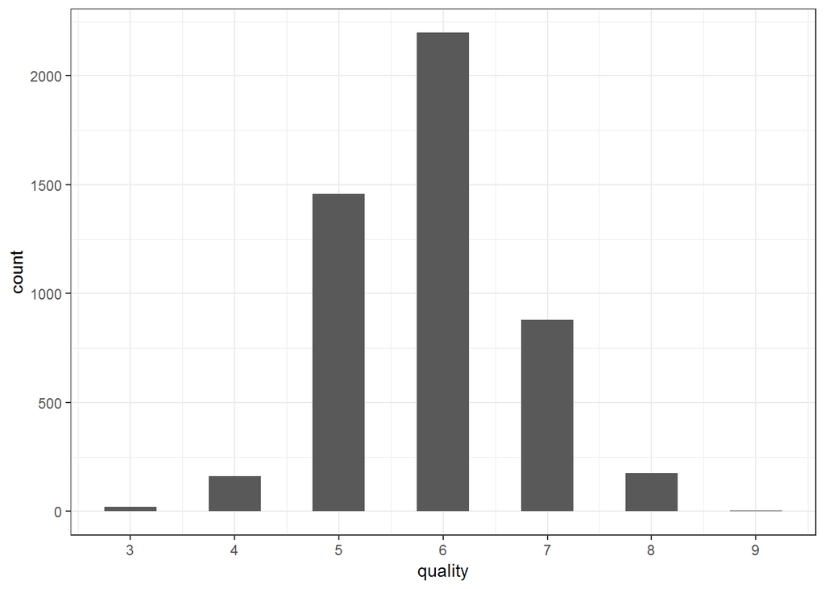

```
##    Min. 1st Qu.  Median    Mean 3rd Qu.    Max.
##   3.000   5.000   6.000   5.878   6.000   9.000
```

```
##
##    3    4    5    6    7    8    9
##   20  163 1457 2198  880  175    5
```

A média da qualidade dos vinhos analisados é 5,878, numa escala de 0 a 10. A grande maioria dos vinhos possui qualidade entre 5 e 7. O pior vinho possui qualidade 3, e o melhor, 9.

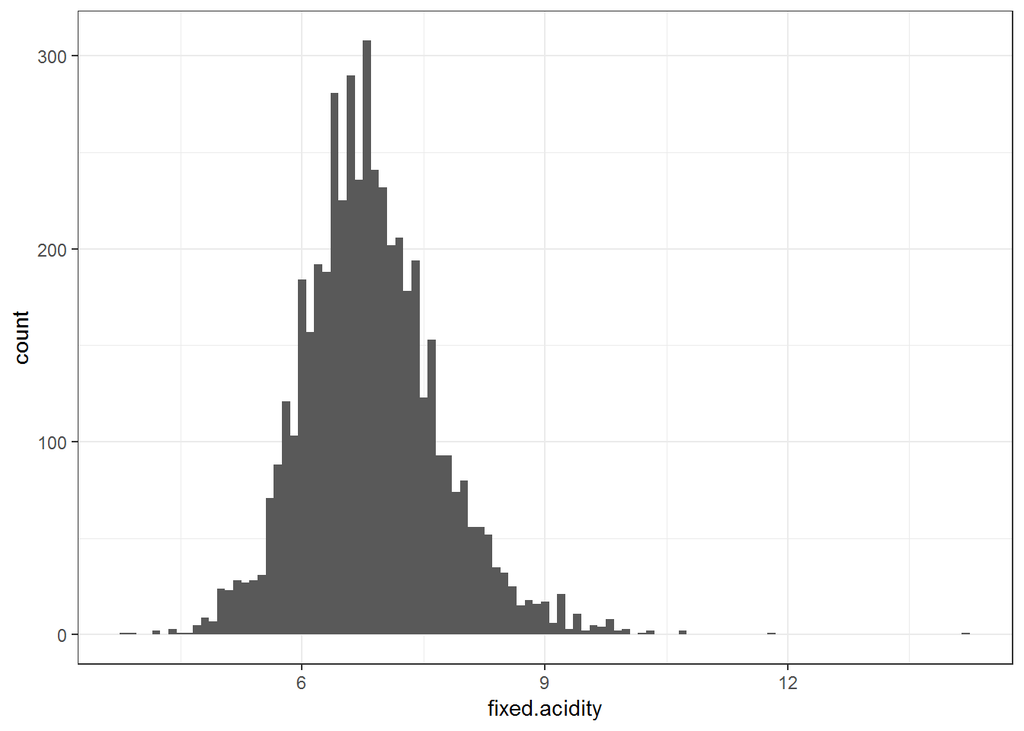

```
##    Min. 1st Qu.  Median    Mean 3rd Qu.    Max.
##   3.800   6.300   6.800   6.855   7.300  14.200
```

```
##
## TRUE
## 4898
```

A acidez fixa apresenta uma distribuição normal centrada em 6,8g/L, com a maioria dos valores variando entre 6,3 e 7,3g/L. Outilers chegam a 14,2g/L.

Todos os vinhos do conjunto de dados obedecem à regulação para a acidez fixa.

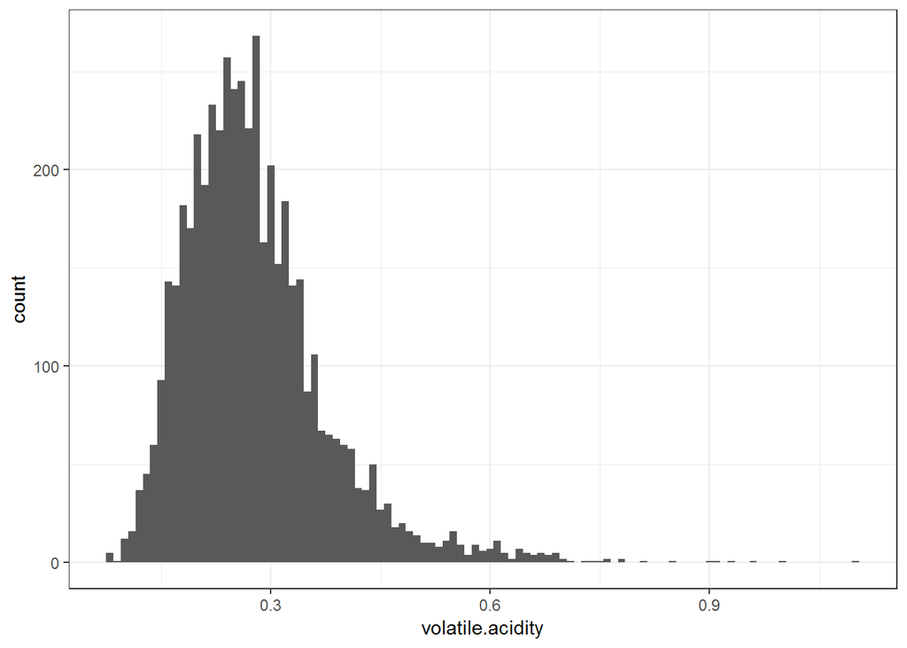

```
##    Min. 1st Qu.  Median    Mean 3rd Qu.    Max.
##  0.0800  0.2100  0.2600  0.2782  0.3200  1.1000
```

```
##
## FALSE  TRUE
##     1  4897
```

A acidez volátil média é de 0.2782g/L. A maioria dos valores se encontra entre 0.21 e 0.32g/L. O menor valor é de 0.08, e o maior de 1.1g/L.

Apenas um vinho não obedece aos padrões exigidos para a acidez volátil.

Em breve, vamos investigar a relação entre acidez fixa e volátil.

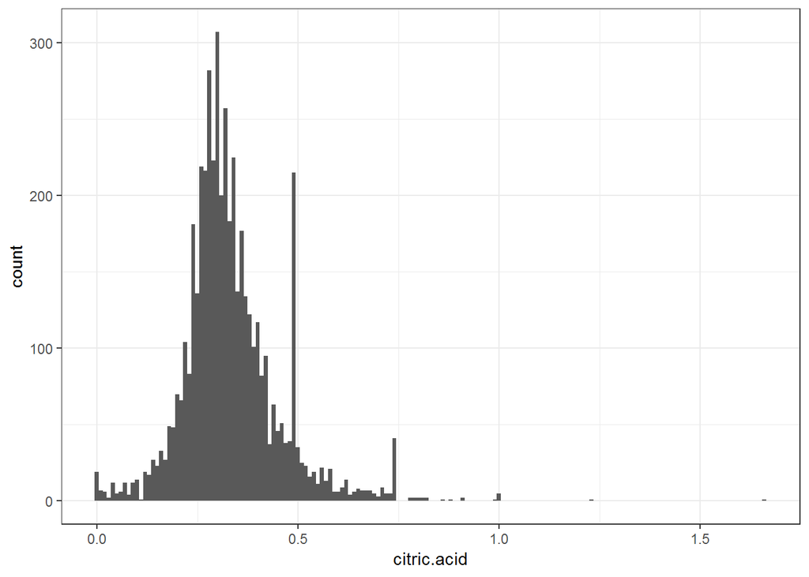

```
##    Min. 1st Qu.  Median    Mean 3rd Qu.    Max.
##  0.0000  0.2700  0.3200  0.3342  0.3900  1.6600
```

```
##
## FALSE  TRUE
##     2  4896
```

A concentração média de ácido cítrico é 0.3342g/L. A maioria dos valores se encontra entre 0.27 e 0.39g/L. O menor valor é de 0, e o maior de 1.66g/L. A distribuição parece tender à normal, ressalvando-se as quantidades atípicas para os valores de 0.49 e 0.74g/L.

Dois vinhos estão fora dos padrões para concentração de ácido cítrico.

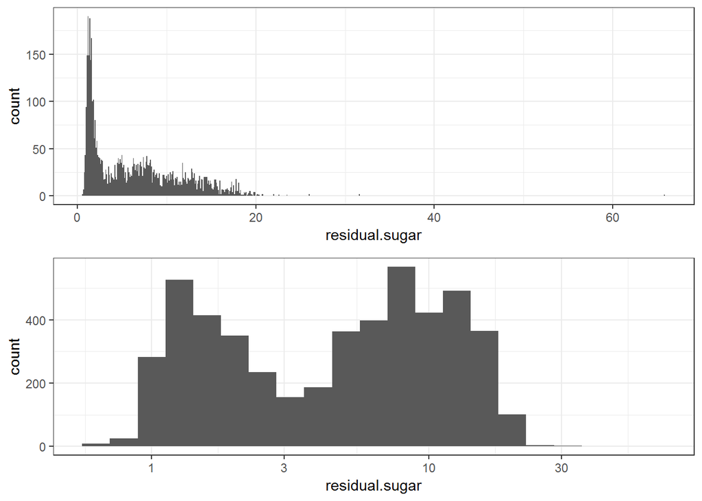

```
##    Min. 1st Qu.  Median    Mean 3rd Qu.    Max.
##   0.600   1.700   5.200   6.391   9.900  65.800
```

Os valores da média e da mediana sugerem uma distribuição de cauda longa, confirmada na visualização. A transformação logarítmica do gráfico gera uma distribuição bimodal, com picos entre 1 e 2, e outro próximo a 10.

A partir das concentrações de açucar residual e acidez fixa, podem-se classificar os vinhos em seco, meio seco, meio doce e doce.

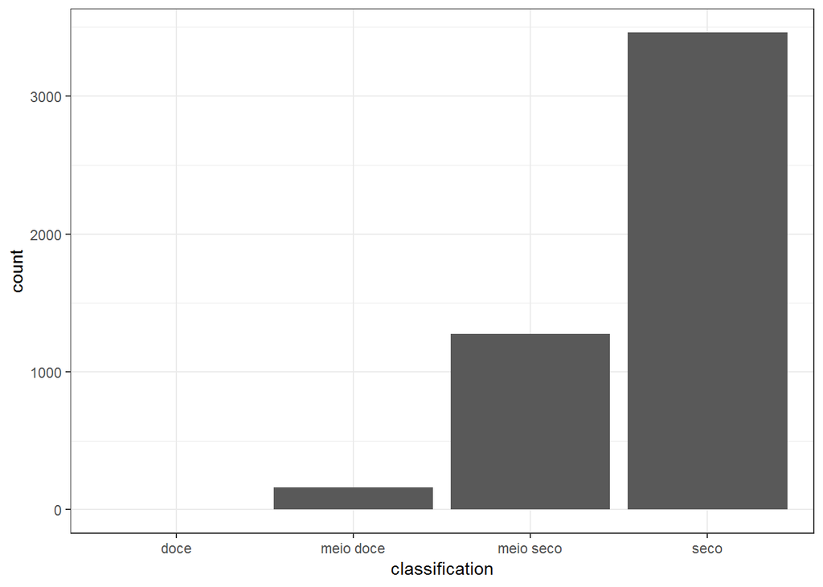

```
##
##      doce meio doce meio seco      seco
##         1       163      1273      3461
```

A maioria é composta por vinho do tipo seco, seguida na ordem pelos meio secos, os meio doces e os doces, com apenas uma ocorrência.

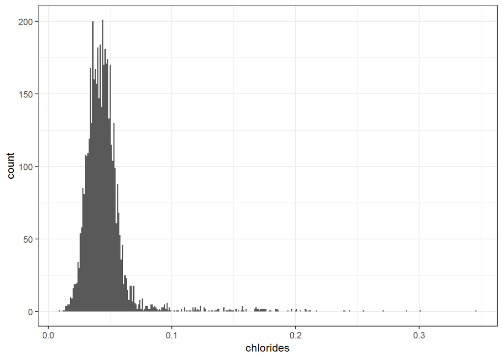

```
##    Min. 1st Qu.  Median    Mean 3rd Qu.    Max.
## 0.00900 0.03600 0.04300 0.04577 0.05000 0.34600
```

```
##
## TRUE
## 4898
```

A concentração de cloreto de sódio apresenta uma distribuição aproximadamente normal centrada próxima a 0,04g/L.

Todos os vinhos do conjunto de dados obedecem à regulação para os cloretos.

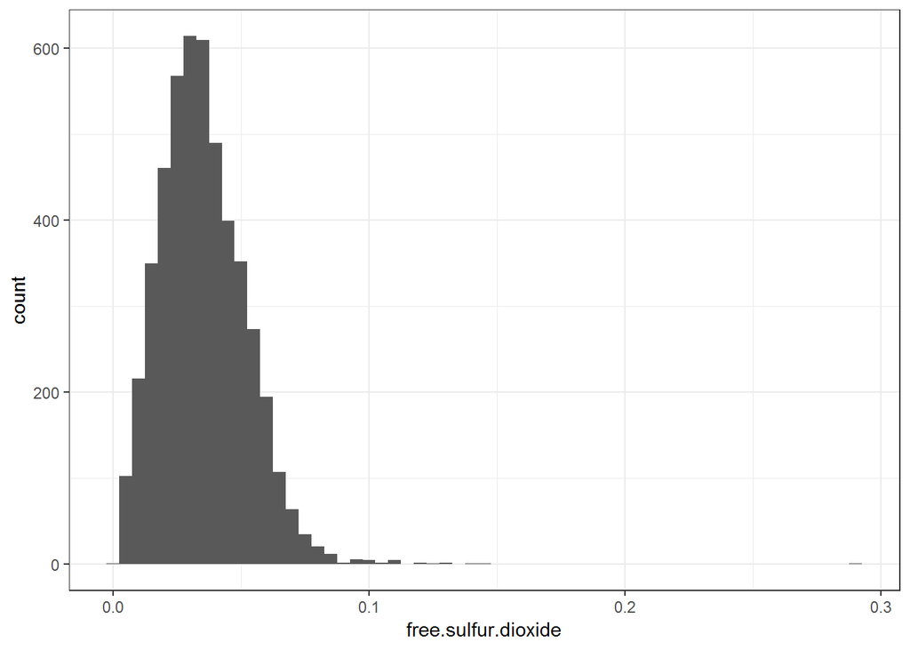

```
##    Min. 1st Qu.  Median    Mean 3rd Qu.    Max.
## 0.00200 0.02300 0.03400 0.03531 0.04600 0.28900
```

A concentração de dióxido de enxofre livre apresenta uma distribuição aproximadamente normal, centrada perto de 0,035g/L.

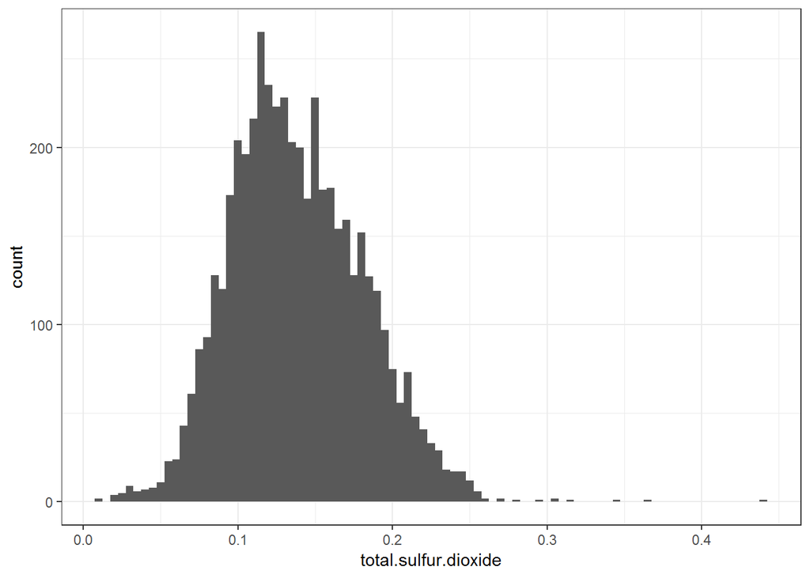

```
##    Min. 1st Qu.  Median    Mean 3rd Qu.    Max.
##  0.0090  0.1080  0.1340  0.1384  0.1670  0.4400
```

```
##
## FALSE  TRUE
##    63  4835
```

A concentração total de dióxido de enxofre apresenta uma distribuição normal centrada em 0,13.

Sessenta e três vinhos estão além do limite permitido para esta concentração.

Espera-se observar adiante alguma correlação entre as concentrações livres e totais dessa substância.

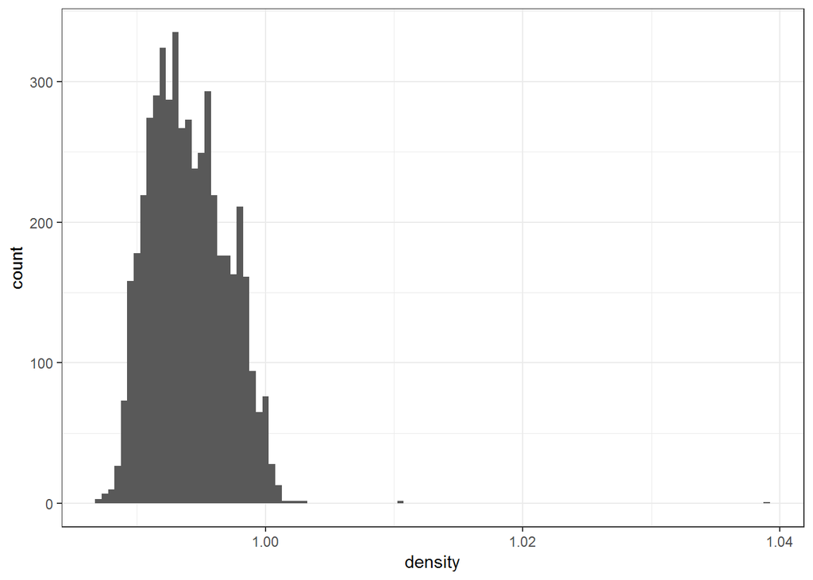

```
##    Min. 1st Qu.  Median    Mean 3rd Qu.    Max.
##  0.9871  0.9917  0.9937  0.9940  0.9961  1.0390
```

A densidade apresenta uma distribuição normal centrada em aproximadamente 0,994g/cm<sup>3</sup>. Posteriormente, investigar-se-á a sua relação com a porcentagem de álcool no vinho.

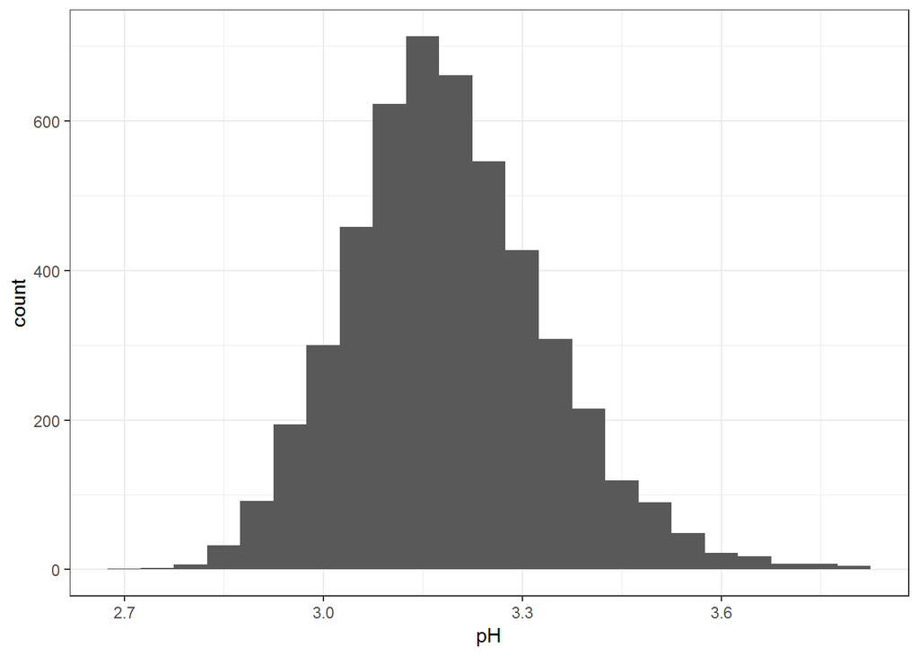

```
##    Min. 1st Qu.  Median    Mean 3rd Qu.    Max.
##   2.720   3.090   3.180   3.188   3.280   3.820
```

O pH apresenta uma distribuição normal centrada em aproximadamente 3,18. Espera-se observar uma forte correlação entre essa variável e a acidez fixa.

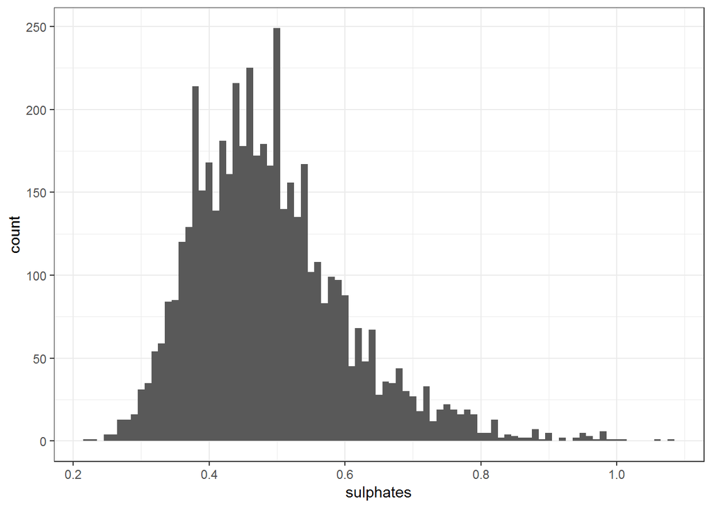

```
##    Min. 1st Qu.  Median    Mean 3rd Qu.    Max.
##  0.2200  0.4100  0.4700  0.4898  0.5500  1.0800
```

```
##
## TRUE
## 4898
```

A concentração de sulfato de potássio apresenta uma distribuição aproximadamente normal, com alguns valores específicos se destacando, principalmente em torno de 0,5g/L, que está a direita do centro da distribuição.

Todos os vinhos do conjunto de dados obedecem à regulação para os sulfatos.

Adiante, veremos como essa variável se relaciona com o dióxido de enxofre.

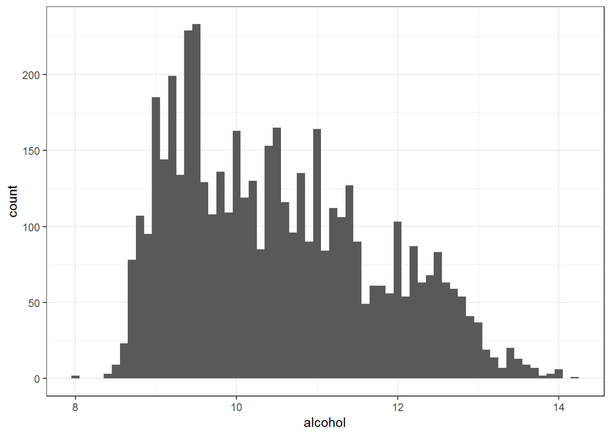

```
##    Min. 1st Qu.  Median    Mean 3rd Qu.    Max.
##    8.00    9.50   10.40   10.51   11.40   14.20
```

```
##
## FALSE  TRUE
##   317  4581
```

A porcentagem de álcool apresenta uma distribuição skewed positiva com bastante ruído, e com o pico em aproximadamente 9,5%.

Do total de vinhos, 317 estão fora dos limites estabelecidos pela regulação para a porcentagem de álcool.

```
##
##    0    1    2
## 4522  369    7
```

Do total de 4898 vinhos desta análise, 4522 passaram em todos os testes, 369 reprovaram em apenas um teste e 7 reprovaram em dois testes.

# Análise Univariada

### Qual é a estrutura do conjunto de dados?

O conjunto de dados possui 4898 observações de 11 variáveis numéricas (atributos) e 1 variável inteira (alvo).

### Quais são os principais atributos de interesse deste conjunto de dados?

O pH (medida de acidez), o teor alcóolico, o açúcar e o sal. Além de, é claro, a qualidade.

### Quais outros atributos você acha que podem lhe auxiliar na investigação destes atributos de interesse?

Os atributos que descrevem a concentração de ácidos no vinho podem ajudar a explicar o pH. Além disso, espera-se que teor alcóolico e concentração de açúcar se expliquem mutuamente, uma vez que a fermentação alcóolica transforma o açúcar da uva em álcool.

### Você criou novas variáveis a partir dos atributos existentes no conjunto de dados?

Sim. Tendo em vista os limites estabelecidos por lei para vinhos em Portugal, criei variáveis lógicas para testar cada atributo com relação a esses limites, e uma variável inteira com a quantidade aprovações para cada vinho. Também classifiquei os vinhos em seco, meio seco, meio doce e doce, a partir das concentrações de açúcar residual e acidez fixa, com base da legislação (http://www.ivv.gov.pt/np4/89/).

### Dos atributos investigados, distribuições incomuns foram encontradas? Você aplicou operações nos dados para limpá-los, ajustá-los ou mudar a forma dos dados? Se sim, por quê?

A distribuição menos comum encontrada foi a da porcentagem de álcool. Pareceu-me próxima a uma skewed positiva, porém com bastante ruído. Não fiz nenhuma alteração nos dados ou no gráfico.

# Seção de Gráficos Bivariados

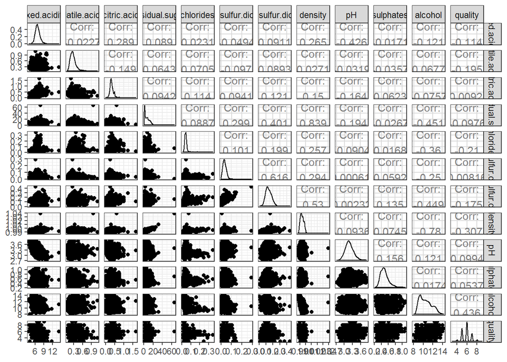

As maiores correlações encontradas são entre densidade e açucar residual (0.839), densidade e álcool (-0.78) e dióxido de enxofre livre e total (0.616). Mostraremos mais adiante como as duas primeiras se relacionam. A terceira é auto-evidente, pois a concentração de um está contida na do outro.

O atributo que a princípio possui a maior correlação com a qualidade é o teor alcóolico (0,436), seguido pela densidade (-0,307) e o nível de sal (-0,21). A seguir, iremos investigar mais a fundo como cada um desses atributos se relaciona com a qualidade, nosso alvo.

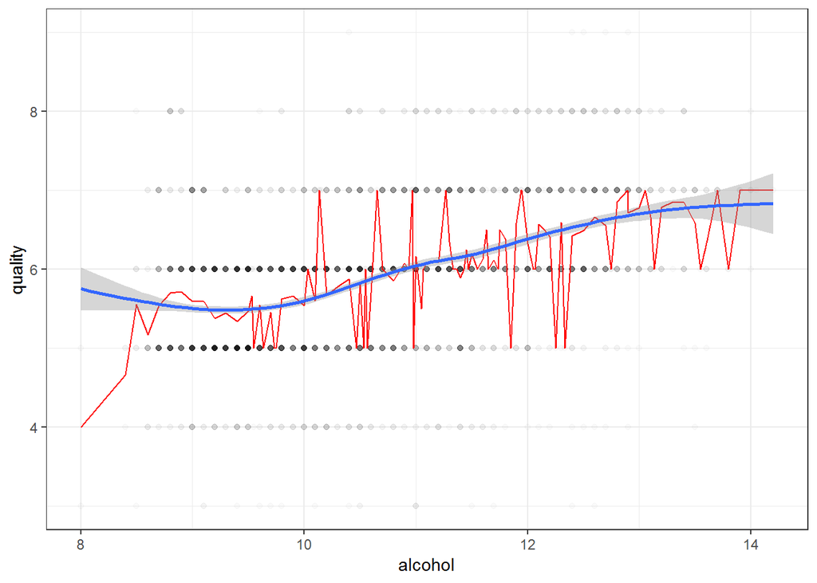

```
## [1] 0.4355747
```

Plotando uma dispersão de qualidade por concentração de álcool, observamos um perfil crescente, que é confirmado pela quase linear curva de suavização da média.

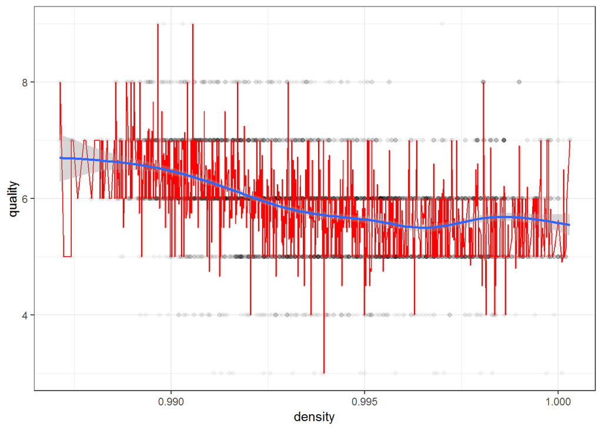

```
## [1] -0.3071233
```

Plotando uma dispersão de qualidade por densidade, observamos um perfil decrescente, salvo uma suave inflexão próxima de 0,997g/L.

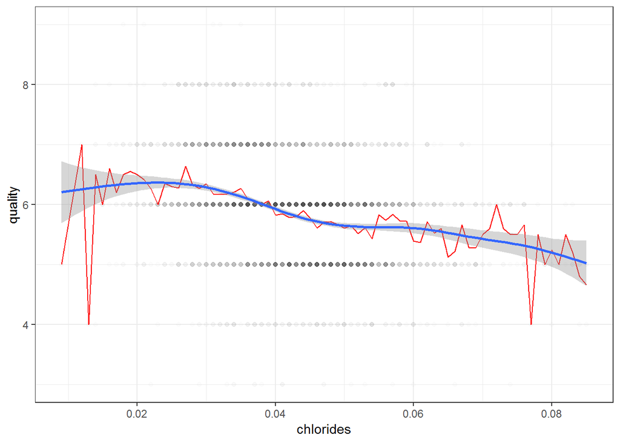

[output not shown]

Plotando uma dispersão de qualidade por concentração de sal, observamos um perfil decrescente, salvo um intervalo aproximadamente constante entre 0,05 0,06g/L.

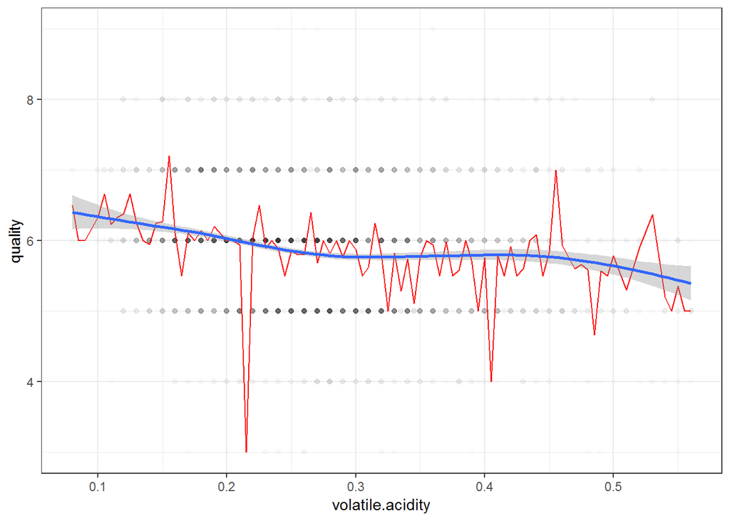

```
## [1] -0.194723
```

Quanto maior a acidez volátil, pior a qualidade, salvo entre os valores 0,25 e 0,45g/L de acidez volátil, onde a qualidade média fica aproximadamente constante. Adiante, iremos investigar esse fenômeno.

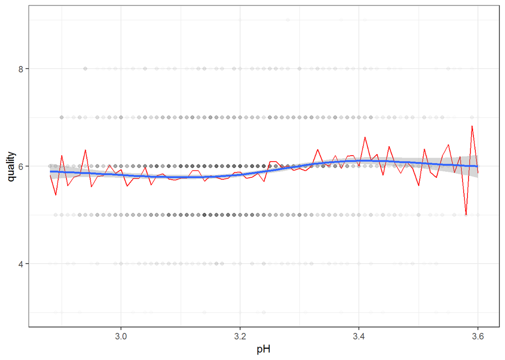

```
## [1] 0.09942725
```

A relação entre pH e qualidade é bastante sutil, mas percebe-se um discreto pico entre os vinhos mais alcalinos.

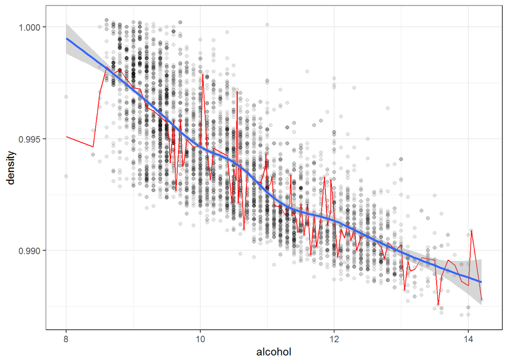

```
## [1] -0.7801376
```

Como era de se esperar, há uma forte correlação inversa entre porcentagem de álcool e densidade, uma vez que a densidade do álcool é menor que a da água.

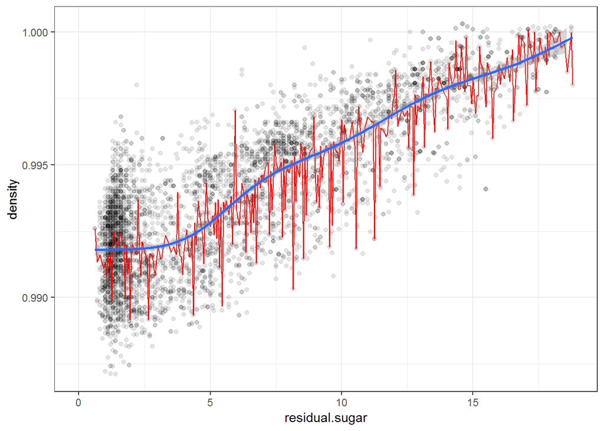

```
## [1] 0.8389665
```

Podemos observar uma forte correlação direta entre o açucar residual e a densidade. Isso também já era esperado, pois a concentração de açucar residual é, a princípio, inversamente proporional à de álcool, uma vez que um dá origem ao outro por meio da fermentação alcóolica.

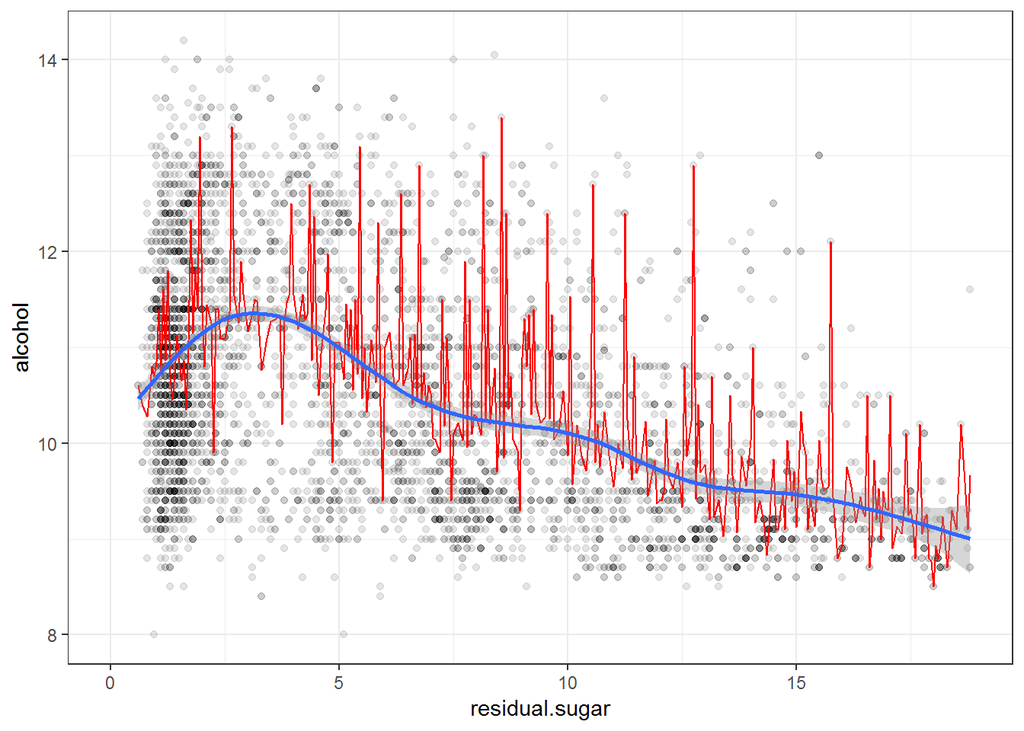

```
## [1] -0.4506312
```

Ao contrário do que supúnhamos, a correlação entre álcool e açúcar residual não é estritamente decresente, sendo crescente até aproximadamente 3g/L de açúcar residual. Provavelmente, isso ocorre em função dos diferentes tipos de uva utilizados na produção do vinho verde, com cada um tendo a sua concentração inicial de açúcar.

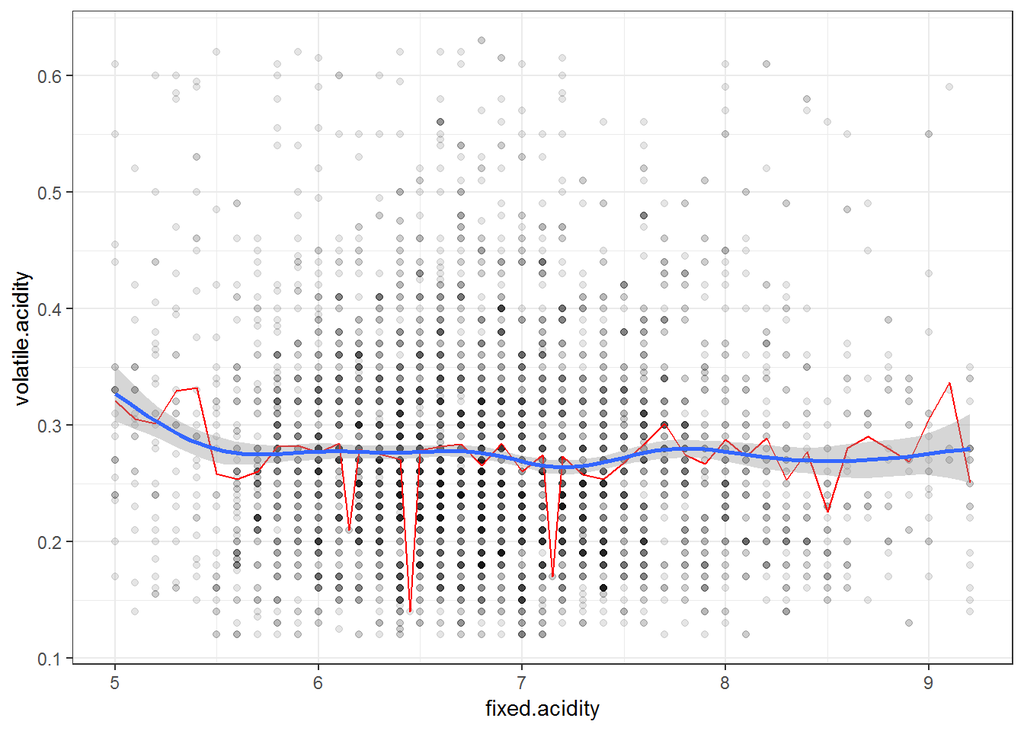

```
## [1] -0.02269729
```

Não há aparente correlação entre acidez fixa e volátil, o que pode ser constatado pela constância da curva suavizada da média da acidez volátil em relação à acidez fixa.

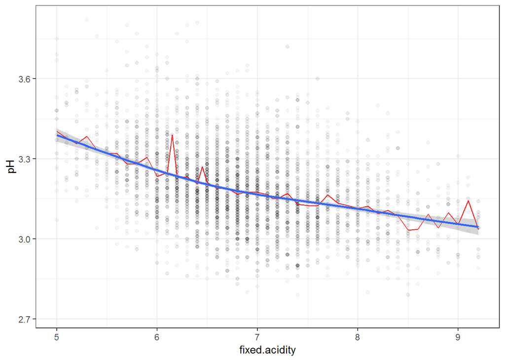

```
## [1] -0.4258583
```

Bastante significativa é a correlação entre acidez fixa e pH, conforme aventamos anteriormente. O gráfico mostra uma relação da média de pH por acidez fixa estritamente decrescente e quase linear. Lembrando que quanto mais ácida uma solução, menor é o pH.

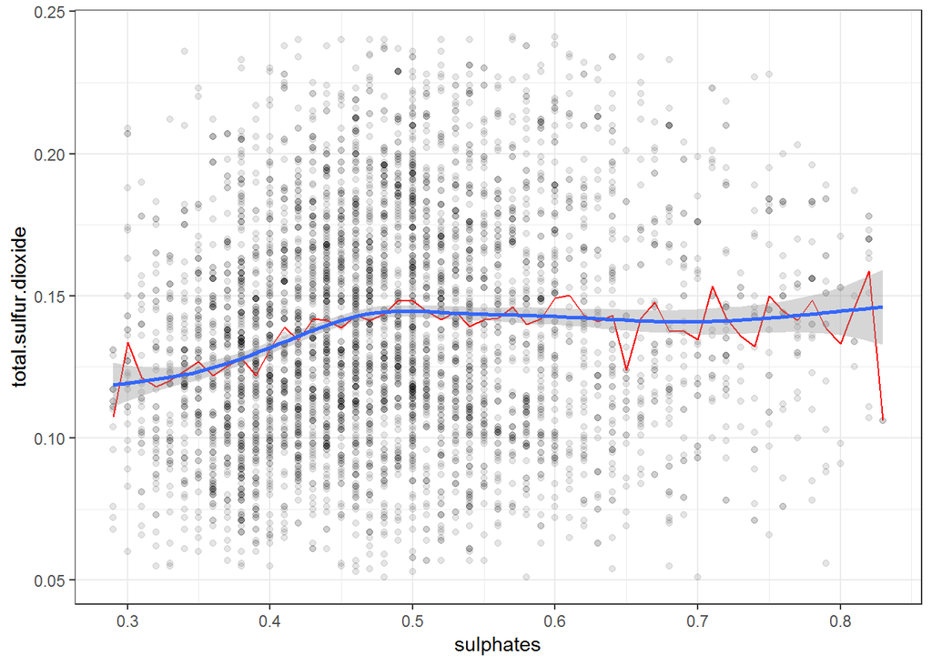

```
## [1] 0.1345624
```

Entre as concentrações de sulfato de potássio e dióxido de enxofre, vemos uma relação crescente até o valor de aproximadamente 0,5g/L para o primeiro, a partir de onde ela passa a ser quase constante.

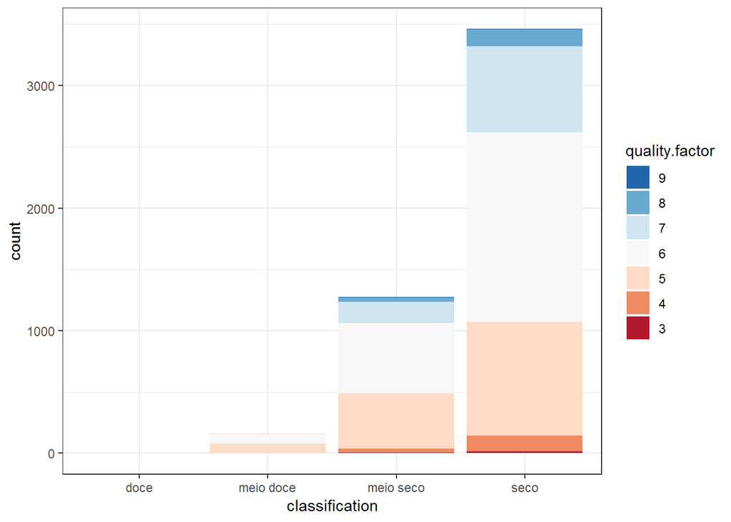

```
## # A tibble: 4 x 3
##   classification quality_mean     n
##   <fct>                 <dbl> <int>
## 1 doce                   6        1
## 2 meio doce              5.57   163
## 3 meio seco              5.78  1273
## 4 seco                   5.93  3461
```

Analisando a qualidade dos vinhos a partir da sua classificação, podemos ver que os vinhos secos têm uma proporção maior de notas 7 e 8 que os meio secos, e estes, maior que os meio doces. Isso reflete na qualidade média de cada tipo. Não podemos considerar a qualidade média dos vinhos doces, pois só há um exemplar desse tipo no conjunto de dados.

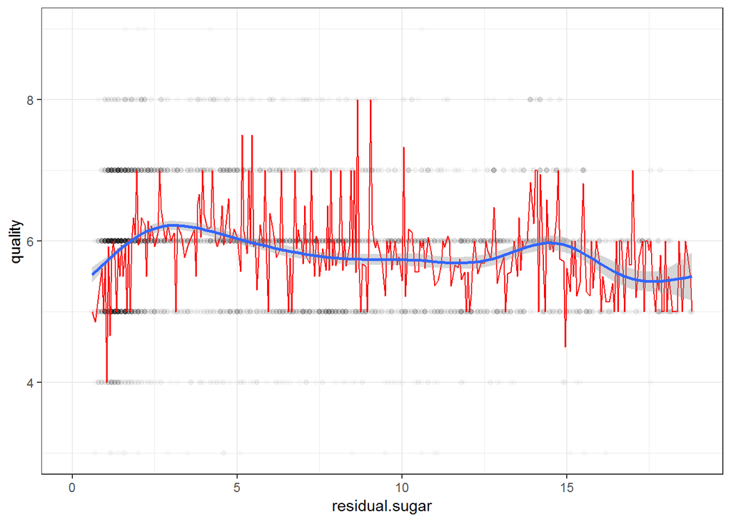

```
## [1] -0.09757683
```

Investigando a variável mais determinante para a classificação vinho (açucar residual), não vemos uma correlação muito clara, no entanto, podemos notar por exemplo um pico nas concentrações mais baixas de açucar, onde se encontram os vinhos secos.

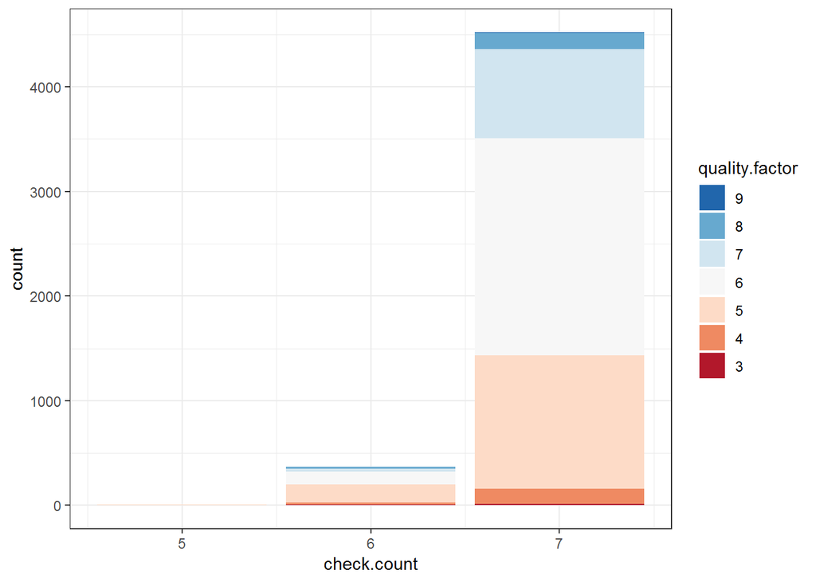

```
## # A tibble: 3 x 3
##   check.count quality_mean     n
##         <int>        <dbl> <int>
## 1           5         5.14     7
## 2           6         5.55   369
## 3           7         5.91  4522
```

# Análise Bivariada

### Discuta sobre alguns dos relacionamentos observados nesta parte da investigação. Como os atributos de interesse variaram no conjunto de dados?

O atributo de maior interesse, a qualidade, está bastante correlacionado com o teor alcóolico. Este, por sua vez, pode ser estimado pelo açucar residual, numa relação inversa, em virtude da fermentação alcóolica. A densidade demonstrou estar dependente do teor alcóolico, por conta da diferença de densidade entre álcool e água. Por conta disso, a densidade também está consideravelmente correlacionada com a qualidade e com o açucar residual. Este, por outro lado, não mostrou ter com a qualidade uma correlação forte. No entanto, menores concentrações daquele parecem ter agradado mais os avaliadores. Outro atributo que em menores concentrações tende a agradar mais é o sal. Por fim, a relação entre pH e qualidade mostrou-se sutil, mas pôde-se constatar uma leve predileção dos avaliadores pelos vinhos menos ácidos.

### Você observou algum relacionamento interessante entre os outros atributos (os que não são de interesse)?

A terceira maior correlação observada foi entre as concentrações de dióxido de enxofre livre e total, o que já era de se esperar, pois uma está contida na outra.

### Qual foi o relacionamento mais forte encontrado?

A maior correlação encontrada (0,839) foi entre densidade e açucar residual.